# Overview

Dataset info

| Number of variables | 34 |
| --- | --- |
| Number of observations | 14359 |
| Total Missing (%) | 10.3% |
| Total size in memory | 3.3 MiB |
| Average record size in memory | 244.0 B |

Variables types

| Numeric | 24 |
| --- | --- |
| Categorical | 3 |
| Boolean | 3 |
| Date | 0 |
| Text (Unique) | 0 |
| Rejected | 4 |
| Unsupported | 0 |

Warnings

- `AvailableBankcardCredit` has 704 / 4.9% zeros Zeros
- `CreditScoreRangeUpper` is highly correlated with `CreditScoreRangeLower` (ρ = 1) Rejected
- `CurrentDelinquencies` has 11650 / 81.1% zeros Zeros
- `DebtToIncomeRatio` has 1689 / 11.8% missing values Missing
- `MonthlyLoanPayment` is highly correlated with `LoanOriginalAmount` (ρ = 0.90506) Rejected
- `OpenRevolvingAccounts` has 234 / 1.6% zeros Zeros
- `ProsperPaymentsOneMonthPlusLate` has 9723 / 67.7% missing values Missing
- `ProsperPaymentsOneMonthPlusLate` has 4524 / 31.5% zeros Zeros
- `ProsperPrincipalBorrowed` has 9723 / 67.7% missing values Missing
- `ProsperPrincipalOutstanding` has 9723 / 67.7% missing values Missing
- `ProsperPrincipalOutstanding` has 1361 / 9.5% zeros Zeros
- `RevolvingCreditBalance` has 699 / 4.9% zeros Zeros
- `ScorexChangeAtTimeOfListing` has 9739 / 67.8% missing values Missing
- `StatedMonthlyIncome` has 225 / 1.6% zeros Zeros
- `StatedMonthlyIncome` is highly skewed (γ1 = 97.603) Skewed
- `TotalInquiries` has 1303 / 9.1% zeros Zeros
- `TotalProsperLoans` has 9723 / 67.7% missing values Missing
- `home+income` has 1113 / 7.8% zeros Zeros
- `indebtedness_rate` is highly correlated with `StatedMonthlyIncome` (ρ = 0.95013) Rejected
- `reliable` is highly correlated with `home+income` (ρ = 0.91271) Rejected

# Variables

AvailableBankcardCredit  
Numeric

| Distinct count | 8954 |
| --- | --- |
| Unique (%) | 62.4% |
| Missing (%) | 0.0% |
| Missing (n) | 0 |
| Infinite (%) | 0.0% |
| Infinite (n) | 0 |

| Mean | 10656 |
| --- | --- |
| Minimum | 0 |
| Maximum | 498370 |
| Zeros (%) | 4.9% |

Toggle details

**Statistics**

Quantile statistics

| Minimum | 0 |
| --- | --- |
| 5-th percentile | 4.9 |
| Q1 | 738 |
| Median | 3749 |
| Q3 | 12740 |
| 95-th percentile | 43091 |
| Maximum | 498370 |
| Range | 498370 |
| Interquartile range | 12002 |

Descriptive statistics

| Standard deviation | 19260 |
| --- | --- |
| Coef of variation | 1.8075 |
| Kurtosis | 91.283 |
| Mean | 10656 |
| MAD | 11237 |
| Skewness | 6.4931 |
| Sum | 153000000 |
| Variance | 370960000 |
| Memory size | 112.3 KiB |

**Histogram**

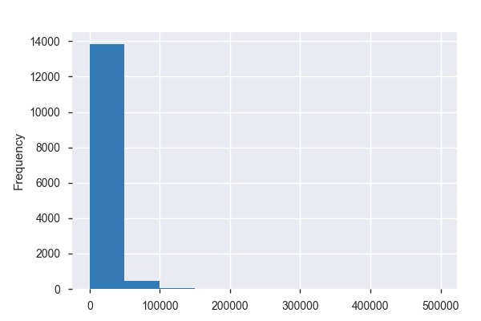

**Common Values**

| Value | Count | Frequency (%) |  |
| --- | --- | --- | --- |
| 0.0 | 704 | 4.9% |  |
| 500.0 | 83 | 0.6% |  |
| 300.0 | 45 | 0.3% |  |
| 2000.0 | 36 | 0.3% |  |
| 1000.0 | 27 | 0.2% |  |
| 1500.0 | 19 | 0.1% |  |
| 3000.0 | 17 | 0.1% |  |
| 19.0 | 15 | 0.1% |  |
| 2500.0 | 15 | 0.1% |  |
| 145.0 | 14 | 0.1% |  |
| Other values (8944) | 13384 | 93.2% |  |

**Extreme Values**

Minimum 5 values

| Value | Count | Frequency (%) |  |
| --- | --- | --- | --- |
| 0.0 | 704 | 4.9% |  |
| 1.0 | 4 | 0.0% |  |
| 2.0 | 1 | 0.0% |  |
| 3.0 | 3 | 0.0% |  |
| 4.0 | 6 | 0.0% |  |

Maximum 5 values

| Value | Count | Frequency (%) |  |
| --- | --- | --- | --- |
| 364284.0 | 1 | 0.0% |  |
| 373348.0 | 1 | 0.0% |  |
| 406125.0 | 1 | 0.0% |  |
| 412785.0 | 1 | 0.0% |  |
| 498374.0 | 1 | 0.0% |  |

BorrowerState  
Categorical

| Distinct count | 48 |
| --- | --- |
| Unique (%) | 0.3% |
| Missing (%) | 0.0% |
| Missing (n) | 0 |

| CA | 1775 |
| --- | --- |
| FL | 947 |
| NY | 925 |
| Other values (45) | 10712 |

Toggle details

| Value | Count | Frequency (%) |  |
| --- | --- | --- | --- |
| CA | 1775 | 12.4% |  |
| FL | 947 | 6.6% |  |
| NY | 925 | 6.4% |  |
| TX | 873 | 6.1% |  |
| IL | 764 | 5.3% |  |
| GA | 608 | 4.2% |  |
| OH | 551 | 3.8% |  |
| VA | 506 | 3.5% |  |
| NC | 455 | 3.2% |  |
| NJ | 438 | 3.1% |  |
| Other values (38) | 6517 | 45.4% |  |

CreditScoreRangeLower  
Numeric

| Distinct count | 15 |
| --- | --- |
| Unique (%) | 0.1% |
| Missing (%) | 0.0% |
| Missing (n) | 0 |
| Infinite (%) | 0.0% |
| Infinite (n) | 0 |

| Mean | 701.45 |
| --- | --- |
| Minimum | 600 |
| Maximum | 880 |
| Zeros (%) | 0.0% |

Toggle details

**Statistics**

Quantile statistics

| Minimum | 600 |
| --- | --- |
| 5-th percentile | 620 |
| Q1 | 660 |
| Median | 700 |
| Q3 | 740 |
| 95-th percentile | 800 |
| Maximum | 880 |
| Range | 280 |
| Interquartile range | 80 |

Descriptive statistics

| Standard deviation | 53.447 |
| --- | --- |
| Coef of variation | 0.076194 |
| Kurtosis | -0.28343 |
| Mean | 701.45 |
| MAD | 43.35 |
| Skewness | 0.43331 |
| Sum | 10072000 |
| Variance | 2856.5 |
| Memory size | 112.3 KiB |

**Histogram**

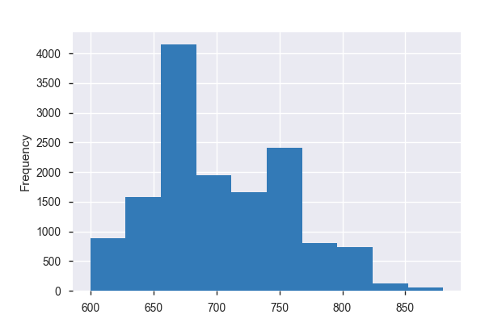

**Common Values**

| Value | Count | Frequency (%) |  |
| --- | --- | --- | --- |
| 660.0 | 2165 | 15.1% |  |
| 680.0 | 1983 | 13.8% |  |
| 700.0 | 1952 | 13.6% |  |
| 720.0 | 1667 | 11.6% |  |
| 640.0 | 1581 | 11.0% |  |
| 740.0 | 1409 | 9.8% |  |
| 760.0 | 1003 | 7.0% |  |
| 780.0 | 801 | 5.6% |  |
| 620.0 | 520 | 3.6% |  |
| 800.0 | 461 | 3.2% |  |
| Other values (5) | 817 | 5.7% |  |

**Extreme Values**

Minimum 5 values

| Value | Count | Frequency (%) |  |
| --- | --- | --- | --- |
| 600.0 | 361 | 2.5% |  |
| 620.0 | 520 | 3.6% |  |
| 640.0 | 1581 | 11.0% |  |
| 660.0 | 2165 | 15.1% |  |
| 680.0 | 1983 | 13.8% |  |

Maximum 5 values

| Value | Count | Frequency (%) |  |
| --- | --- | --- | --- |
| 800.0 | 461 | 3.2% |  |
| 820.0 | 280 | 1.9% |  |
| 840.0 | 116 | 0.8% |  |
| 860.0 | 53 | 0.4% |  |
| 880.0 | 7 | 0.0% |  |

CreditScoreRangeUpper  
Highly correlated

*This variable is highly correlated with `CreditScoreRangeLower` and should be ignored for analysis*

| Correlation | 1 |
| --- | --- |

CurrentCreditLines  
Numeric

| Distinct count | 43 |
| --- | --- |
| Unique (%) | 0.3% |
| Missing (%) | 0.0% |
| Missing (n) | 0 |
| Infinite (%) | 0.0% |
| Infinite (n) | 0 |

| Mean | 9.403 |
| --- | --- |
| Minimum | 0 |
| Maximum | 56 |
| Zeros (%) | 0.7% |

Toggle details

**Statistics**

Quantile statistics

| Minimum | 0 |
| --- | --- |
| 5-th percentile | 2 |
| Q1 | 6 |
| Median | 9 |
| Q3 | 12 |
| 95-th percentile | 19 |
| Maximum | 56 |
| Range | 56 |
| Interquartile range | 6 |

Descriptive statistics

| Standard deviation | 5.3724 |
| --- | --- |
| Coef of variation | 0.57135 |
| Kurtosis | 2.5078 |
| Mean | 9.403 |
| MAD | 4.151 |
| Skewness | 1.0934 |
| Sum | 135020 |
| Variance | 28.862 |
| Memory size | 112.3 KiB |

**Histogram**

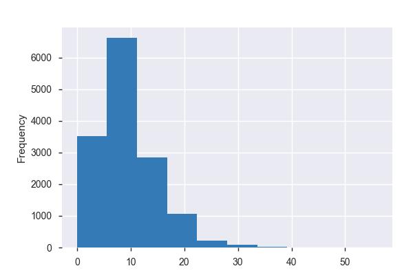

**Common Values**

| Value | Count | Frequency (%) |  |
| --- | --- | --- | --- |
| 8.0 | 1223 | 8.5% |  |
| 7.0 | 1204 | 8.4% |  |
| 6.0 | 1127 | 7.8% |  |
| 9.0 | 1112 | 7.7% |  |
| 10.0 | 1040 | 7.2% |  |
| 5.0 | 1005 | 7.0% |  |
| 4.0 | 920 | 6.4% |  |
| 11.0 | 912 | 6.4% |  |
| 12.0 | 771 | 5.4% |  |
| 3.0 | 721 | 5.0% |  |
| Other values (33) | 4324 | 30.1% |  |

**Extreme Values**

Minimum 5 values

| Value | Count | Frequency (%) |  |
| --- | --- | --- | --- |
| 0.0 | 94 | 0.7% |  |
| 1.0 | 299 | 2.1% |  |
| 2.0 | 473 | 3.3% |  |
| 3.0 | 721 | 5.0% |  |
| 4.0 | 920 | 6.4% |  |

Maximum 5 values

| Value | Count | Frequency (%) |  |
| --- | --- | --- | --- |
| 38.0 | 1 | 0.0% |  |
| 39.0 | 1 | 0.0% |  |
| 44.0 | 1 | 0.0% |  |
| 45.0 | 1 | 0.0% |  |
| 56.0 | 2 | 0.0% |  |

CurrentDelinquencies  
Numeric

| Distinct count | 22 |
| --- | --- |
| Unique (%) | 0.2% |
| Missing (%) | 0.0% |
| Missing (n) | 0 |
| Infinite (%) | 0.0% |
| Infinite (n) | 0 |

| Mean | 0.40616 |
| --- | --- |
| Minimum | 0 |
| Maximum | 27 |
| Zeros (%) | 81.1% |

Toggle details

**Statistics**

Quantile statistics

| Minimum | 0 |
| --- | --- |
| 5-th percentile | 0 |
| Q1 | 0 |
| Median | 0 |
| Q3 | 0 |
| 95-th percentile | 2 |
| Maximum | 27 |
| Range | 27 |
| Interquartile range | 0 |

Descriptive statistics

| Standard deviation | 1.2716 |
| --- | --- |
| Coef of variation | 3.1309 |
| Kurtosis | 67.627 |
| Mean | 0.40616 |
| MAD | 0.65906 |
| Skewness | 6.4679 |
| Sum | 5832 |
| Variance | 1.617 |
| Memory size | 112.3 KiB |

**Histogram**

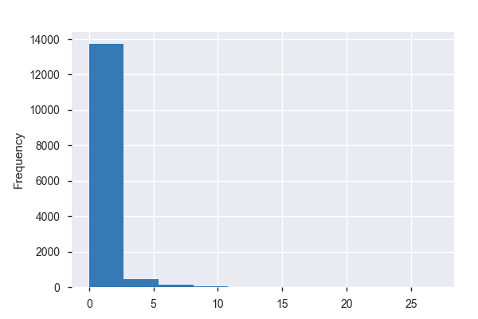

**Common Values**

| Value | Count | Frequency (%) |  |
| --- | --- | --- | --- |
| 0.0 | 11650 | 81.1% |  |
| 1.0 | 1554 | 10.8% |  |
| 2.0 | 517 | 3.6% |  |
| 3.0 | 217 | 1.5% |  |
| 4.0 | 161 | 1.1% |  |
| 5.0 | 68 | 0.5% |  |
| 6.0 | 64 | 0.4% |  |
| 7.0 | 44 | 0.3% |  |
| 8.0 | 25 | 0.2% |  |
| 9.0 | 16 | 0.1% |  |
| Other values (12) | 43 | 0.3% |  |

**Extreme Values**

Minimum 5 values

| Value | Count | Frequency (%) |  |
| --- | --- | --- | --- |
| 0.0 | 11650 | 81.1% |  |
| 1.0 | 1554 | 10.8% |  |
| 2.0 | 517 | 3.6% |  |
| 3.0 | 217 | 1.5% |  |
| 4.0 | 161 | 1.1% |  |

Maximum 5 values

| Value | Count | Frequency (%) |  |
| --- | --- | --- | --- |
| 19.0 | 1 | 0.0% |  |
| 21.0 | 2 | 0.0% |  |
| 22.0 | 1 | 0.0% |  |
| 24.0 | 1 | 0.0% |  |
| 27.0 | 1 | 0.0% |  |

CurrentlyInGroup  
Boolean

| Distinct count | 2 |
| --- | --- |
| Unique (%) | 0.0% |
| Missing (%) | 0.0% |
| Missing (n) | 0 |

| Mean | 0.053764 |
| --- | --- |

| False | 13587 |
| --- | --- |
| True | 772 |

Toggle details

| Value | Count | Frequency (%) |  |
| --- | --- | --- | --- |
| False | 13587 | 94.6% |  |
| True | 772 | 5.4% |  |

DebtToIncomeRatio  
Numeric

| Distinct count | 170 |
| --- | --- |
| Unique (%) | 1.2% |
| Missing (%) | 11.8% |
| Missing (n) | 1689 |
| Infinite (%) | 0.0% |
| Infinite (n) | 0 |

| Mean | 0.24674 |
| --- | --- |
| Minimum | 0 |
| Maximum | 10.01 |
| Zeros (%) | 0.0% |

Toggle details

**Statistics**

Quantile statistics

| Minimum | 0 |
| --- | --- |
| 5-th percentile | 0.06 |
| Q1 | 0.13 |
| Median | 0.19 |
| Q3 | 0.3 |
| 95-th percentile | 0.51 |
| Maximum | 10.01 |
| Range | 10.01 |
| Interquartile range | 0.17 |

Descriptive statistics

| Standard deviation | 0.38729 |
| --- | --- |
| Coef of variation | 1.5696 |
| Kurtosis | 420.05 |
| Mean | 0.24674 |
| MAD | 0.1334 |
| Skewness | 18.204 |
| Sum | 3126.2 |
| Variance | 0.14999 |
| Memory size | 112.3 KiB |

**Histogram**

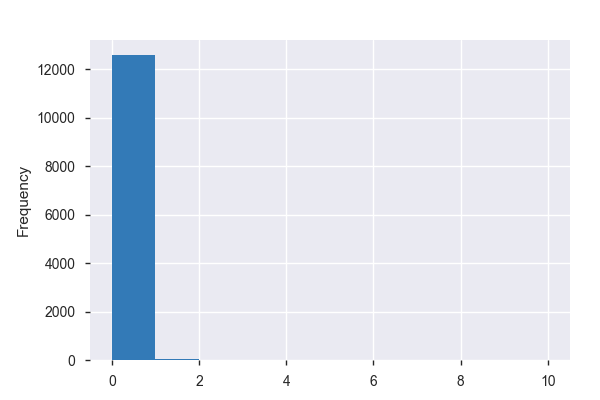

**Common Values**

| Value | Count | Frequency (%) |  |
| --- | --- | --- | --- |
| 0.18 | 593 | 4.1% |  |
| 0.14 | 563 | 3.9% |  |
| 0.22 | 521 | 3.6% |  |
| 0.17 | 500 | 3.5% |  |
| 0.16 | 480 | 3.3% |  |
| 0.13 | 462 | 3.2% |  |
| 0.15 | 432 | 3.0% |  |
| 0.08 | 418 | 2.9% |  |
| 0.11 | 403 | 2.8% |  |
| 0.2 | 382 | 2.7% |  |
| Other values (159) | 7916 | 55.1% |  |
| (Missing) | 1689 | 11.8% |  |

**Extreme Values**

Minimum 5 values

| Value | Count | Frequency (%) |  |
| --- | --- | --- | --- |
| 0.0 | 2 | 0.0% |  |
| 0.01 | 17 | 0.1% |  |
| 0.02 | 71 | 0.5% |  |
| 0.03 | 147 | 1.0% |  |
| 0.04 | 160 | 1.1% |  |

Maximum 5 values

| Value | Count | Frequency (%) |  |
| --- | --- | --- | --- |
| 5.56 | 1 | 0.0% |  |
| 5.64 | 1 | 0.0% |  |
| 7.27 | 1 | 0.0% |  |
| 7.42 | 1 | 0.0% |  |
| 10.01 | 12 | 0.1% |  |

EmploymentStatus  
Categorical

| Distinct count | 7 |
| --- | --- |
| Unique (%) | 0.0% |
| Missing (%) | 0.0% |
| Missing (n) | 0 |

| Employed | 9444 |
| --- | --- |
| Full-time | 3156 |
| Self-employed | 797 |
| Other values (4) | 962 |

Toggle details

| Value | Count | Frequency (%) |  |
| --- | --- | --- | --- |
| Employed | 9444 | 65.8% |  |
| Full-time | 3156 | 22.0% |  |
| Self-employed | 797 | 5.6% |  |
| Other | 480 | 3.3% |  |
| Not employed | 207 | 1.4% |  |
| Retired | 159 | 1.1% |  |
| Part-time | 116 | 0.8% |  |

EmploymentStatusDuration  
Numeric

| Distinct count | 482 |
| --- | --- |
| Unique (%) | 3.4% |
| Missing (%) | 0.1% |
| Missing (n) | 8 |
| Infinite (%) | 0.0% |
| Infinite (n) | 0 |

| Mean | 90.966 |
| --- | --- |
| Minimum | 0 |
| Maximum | 745 |
| Zeros (%) | 0.7% |

Toggle details

**Statistics**

Quantile statistics

| Minimum | 0 |
| --- | --- |
| 5-th percentile | 4 |
| Q1 | 27 |
| Median | 61 |
| Q3 | 127 |
| 95-th percentile | 281 |
| Maximum | 745 |
| Range | 745 |
| Interquartile range | 100 |

Descriptive statistics

| Standard deviation | 88.956 |
| --- | --- |
| Coef of variation | 0.9779 |
| Kurtosis | 3.0777 |
| Mean | 90.966 |
| MAD | 67.284 |
| Skewness | 1.6588 |
| Sum | 1305500 |
| Variance | 7913.2 |
| Memory size | 112.3 KiB |

**Histogram**

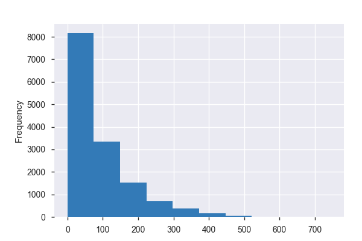

**Common Values**

| Value | Count | Frequency (%) |  |
| --- | --- | --- | --- |
| 3.0 | 176 | 1.2% |  |
| 2.0 | 169 | 1.2% |  |
| 8.0 | 162 | 1.1% |  |
| 6.0 | 159 | 1.1% |  |
| 7.0 | 159 | 1.1% |  |
| 5.0 | 157 | 1.1% |  |
| 4.0 | 149 | 1.0% |  |
| 12.0 | 140 | 1.0% |  |
| 1.0 | 139 | 1.0% |  |
| 14.0 | 137 | 1.0% |  |
| Other values (471) | 12804 | 89.2% |  |

**Extreme Values**

Minimum 5 values

| Value | Count | Frequency (%) |  |
| --- | --- | --- | --- |
| 0.0 | 101 | 0.7% |  |
| 1.0 | 139 | 1.0% |  |
| 2.0 | 169 | 1.2% |  |
| 3.0 | 176 | 1.2% |  |
| 4.0 | 149 | 1.0% |  |

Maximum 5 values

| Value | Count | Frequency (%) |  |
| --- | --- | --- | --- |
| 575.0 | 1 | 0.0% |  |
| 582.0 | 1 | 0.0% |  |
| 610.0 | 1 | 0.0% |  |
| 616.0 | 1 | 0.0% |  |
| 745.0 | 1 | 0.0% |  |

IncomeVerifiable  
Boolean

| Distinct count | 2 |
| --- | --- |
| Unique (%) | 0.0% |
| Missing (%) | 0.0% |
| Missing (n) | 0 |

| Mean | 0.88251 |
| --- | --- |

| True | 12672 |
| --- | --- |
| False | 1687 |

Toggle details

| Value | Count | Frequency (%) |  |
| --- | --- | --- | --- |
| True | 12672 | 88.3% |  |
| False | 1687 | 11.7% |  |

Investors  
Numeric

| Distinct count | 527 |
| --- | --- |
| Unique (%) | 3.7% |
| Missing (%) | 0.0% |
| Missing (n) | 0 |
| Infinite (%) | 0.0% |
| Infinite (n) | 0 |

| Mean | 92.295 |
| --- | --- |
| Minimum | 1 |
| Maximum | 866 |
| Zeros (%) | 0.0% |

Toggle details

**Statistics**

Quantile statistics

| Minimum | 1 |
| --- | --- |
| 5-th percentile | 4 |
| Q1 | 29 |
| Median | 63 |
| Q3 | 125 |
| 95-th percentile | 281 |
| Maximum | 866 |
| Range | 865 |
| Interquartile range | 96 |

Descriptive statistics

| Standard deviation | 92.988 |
| --- | --- |
| Coef of variation | 1.0075 |
| Kurtosis | 5.727 |
| Mean | 92.295 |
| MAD | 67.683 |
| Skewness | 2.0239 |
| Sum | 1325265 |
| Variance | 8646.7 |
| Memory size | 112.3 KiB |

**Histogram**

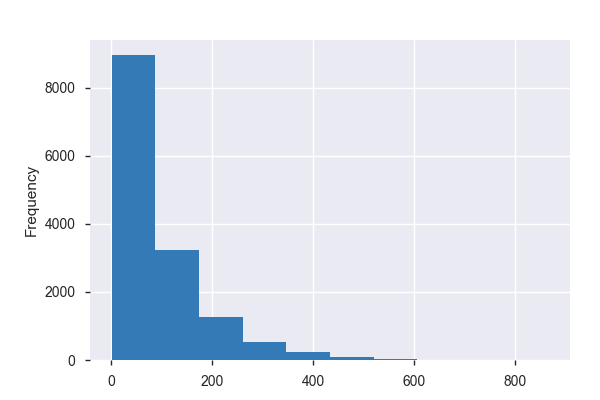

**Common Values**

| Value | Count | Frequency (%) |  |
| --- | --- | --- | --- |
| 1 | 322 | 2.2% |  |
| 2 | 200 | 1.4% |  |
| 8 | 186 | 1.3% |  |
| 7 | 148 | 1.0% |  |
| 5 | 147 | 1.0% |  |
| 4 | 146 | 1.0% |  |
| 9 | 145 | 1.0% |  |
| 10 | 139 | 1.0% |  |
| 37 | 136 | 0.9% |  |
| 27 | 134 | 0.9% |  |
| Other values (517) | 12656 | 88.1% |  |

**Extreme Values**

Minimum 5 values

| Value | Count | Frequency (%) |  |
| --- | --- | --- | --- |
| 1 | 322 | 2.2% |  |
| 2 | 200 | 1.4% |  |
| 3 | 132 | 0.9% |  |
| 4 | 146 | 1.0% |  |
| 5 | 147 | 1.0% |  |

Maximum 5 values

| Value | Count | Frequency (%) |  |
| --- | --- | --- | --- |
| 731 | 1 | 0.0% |  |
| 737 | 1 | 0.0% |  |
| 755 | 1 | 0.0% |  |
| 856 | 1 | 0.0% |  |
| 866 | 1 | 0.0% |  |

IsBorrowerHomeowner  
Boolean

| Distinct count | 2 |
| --- | --- |
| Unique (%) | 0.0% |
| Missing (%) | 0.0% |
| Missing (n) | 0 |

| Mean | 0.51863 |
| --- | --- |

| True | 7447 |
| --- | --- |
| False | 6912 |

Toggle details

| Value | Count | Frequency (%) |  |
| --- | --- | --- | --- |
| True | 7447 | 51.9% |  |
| False | 6912 | 48.1% |  |

LenderYield  
Numeric

| Distinct count | 659 |
| --- | --- |
| Unique (%) | 4.6% |
| Missing (%) | 0.0% |
| Missing (n) | 0 |
| Infinite (%) | 0.0% |
| Infinite (n) | 0 |

| Mean | 0.21308 |
| --- | --- |
| Minimum | 0.0325 |
| Maximum | 0.34 |
| Zeros (%) | 0.0% |

Toggle details

**Statistics**

Quantile statistics

| Minimum | 0.0325 |
| --- | --- |
| 5-th percentile | 0.0735 |
| Q1 | 0.1369 |
| Median | 0.2368 |
| Q3 | 0.2975 |
| 95-th percentile | 0.31481 |
| Maximum | 0.34 |
| Range | 0.3075 |
| Interquartile range | 0.1606 |

Descriptive statistics

| Standard deviation | 0.084088 |
| --- | --- |
| Coef of variation | 0.39462 |
| Kurtosis | -1.1915 |
| Mean | 0.21308 |
| MAD | 0.073888 |
| Skewness | -0.31658 |
| Sum | 3059.7 |
| Variance | 0.0070708 |
| Memory size | 112.3 KiB |

**Histogram**

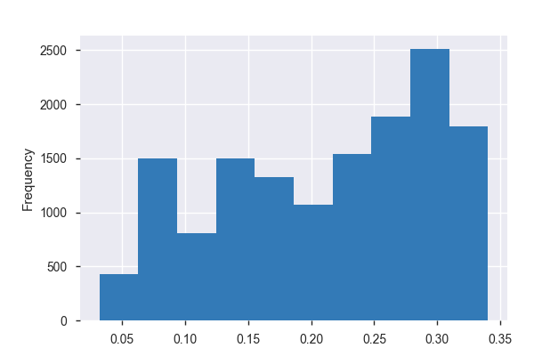

**Common Values**

| Value | Count | Frequency (%) |  |
| --- | --- | --- | --- |
| 0.3099 | 973 | 6.8% |  |
| 0.3077 | 843 | 5.9% |  |
| 0.2599 | 558 | 3.9% |  |
| 0.2499 | 468 | 3.3% |  |
| 0.1349 | 358 | 2.5% |  |
| 0.34 | 340 | 2.4% |  |
| 0.2999 | 292 | 2.0% |  |
| 0.1699 | 266 | 1.9% |  |
| 0.08199999999999999 | 247 | 1.7% |  |
| 0.1949 | 247 | 1.7% |  |
| Other values (649) | 9767 | 68.0% |  |

**Extreme Values**

Minimum 5 values

| Value | Count | Frequency (%) |  |
| --- | --- | --- | --- |
| 0.0325 | 1 | 0.0% |  |
| 0.035 | 1 | 0.0% |  |
| 0.0398 | 1 | 0.0% |  |
| 0.0399 | 22 | 0.2% |  |
| 0.04 | 2 | 0.0% |  |

Maximum 5 values

| Value | Count | Frequency (%) |  |
| --- | --- | --- | --- |
| 0.3394 | 2 | 0.0% |  |
| 0.3395 | 5 | 0.0% |  |
| 0.3398 | 1 | 0.0% |  |
| 0.3399 | 5 | 0.0% |  |
| 0.34 | 340 | 2.4% |  |

ListingCategory (numeric)  
Numeric

| Distinct count | 20 |
| --- | --- |
| Unique (%) | 0.1% |
| Missing (%) | 0.0% |
| Missing (n) | 0 |
| Infinite (%) | 0.0% |
| Infinite (n) | 0 |

| Mean | 3.722 |
| --- | --- |
| Minimum | 0 |
| Maximum | 20 |
| Zeros (%) | 0.0% |

Toggle details

**Statistics**

Quantile statistics

| Minimum | 0 |
| --- | --- |
| 5-th percentile | 1 |
| Q1 | 1 |
| Median | 2 |
| Q3 | 7 |
| 95-th percentile | 13 |
| Maximum | 20 |
| Range | 20 |
| Interquartile range | 6 |

Descriptive statistics

| Standard deviation | 3.9566 |
| --- | --- |
| Coef of variation | 1.063 |
| Kurtosis | 3.9493 |
| Mean | 3.722 |
| MAD | 3.0678 |
| Skewness | 1.9349 |
| Sum | 53444 |
| Variance | 15.655 |
| Memory size | 112.3 KiB |

**Histogram**

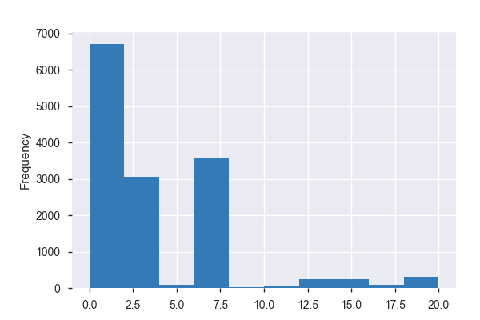

**Common Values**

| Value | Count | Frequency (%) |  |
| --- | --- | --- | --- |
| 1 | 6695 | 46.6% |  |
| 7 | 2843 | 19.8% |  |
| 2 | 1576 | 11.0% |  |
| 3 | 1476 | 10.3% |  |
| 6 | 737 | 5.1% |  |
| 13 | 227 | 1.6% |  |
| 15 | 163 | 1.1% |  |
| 18 | 147 | 1.0% |  |
| 5 | 91 | 0.6% |  |
| 20 | 84 | 0.6% |  |
| Other values (10) | 320 | 2.2% |  |

**Extreme Values**

Minimum 5 values

| Value | Count | Frequency (%) |  |
| --- | --- | --- | --- |
| 0 | 6 | 0.0% |  |
| 1 | 6695 | 46.6% |  |
| 2 | 1576 | 11.0% |  |
| 3 | 1476 | 10.3% |  |
| 5 | 91 | 0.6% |  |

Maximum 5 values

| Value | Count | Frequency (%) |  |
| --- | --- | --- | --- |
| 16 | 75 | 0.5% |  |
| 17 | 9 | 0.1% |  |
| 18 | 147 | 1.0% |  |
| 19 | 82 | 0.6% |  |
| 20 | 84 | 0.6% |  |

LoanMonthsSinceOrigination  
Numeric

| Distinct count | 29 |
| --- | --- |
| Unique (%) | 0.2% |
| Missing (%) | 0.0% |
| Missing (n) | 0 |
| Infinite (%) | 0.0% |
| Infinite (n) | 0 |

| Mean | 32.287 |
| --- | --- |
| Minimum | 22 |
| Maximum | 50 |
| Zeros (%) | 0.0% |

Toggle details

**Statistics**

Quantile statistics

| Minimum | 22 |
| --- | --- |
| 5-th percentile | 23 |
| Q1 | 26 |
| Median | 30 |
| Q3 | 38 |
| 95-th percentile | 48 |
| Maximum | 50 |
| Range | 28 |
| Interquartile range | 12 |

Descriptive statistics

| Standard deviation | 7.8833 |
| --- | --- |
| Coef of variation | 0.24416 |
| Kurtosis | -0.67561 |
| Mean | 32.287 |
| MAD | 6.6037 |
| Skewness | 0.65404 |
| Sum | 463613 |
| Variance | 62.146 |
| Memory size | 112.3 KiB |

**Histogram**

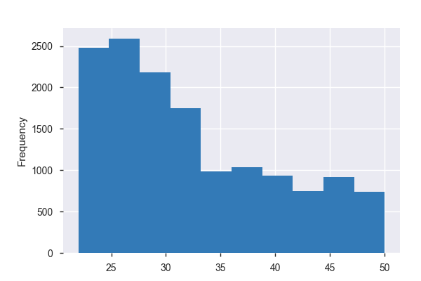

**Common Values**

| Value | Count | Frequency (%) |  |
| --- | --- | --- | --- |
| 23 | 912 | 6.4% |  |
| 26 | 898 | 6.3% |  |
| 24 | 893 | 6.2% |  |
| 25 | 869 | 6.1% |  |
| 27 | 821 | 5.7% |  |
| 28 | 812 | 5.7% |  |
| 29 | 709 | 4.9% |  |
| 22 | 671 | 4.7% |  |
| 30 | 662 | 4.6% |  |
| 31 | 646 | 4.5% |  |
| Other values (19) | 6466 | 45.0% |  |

**Extreme Values**

Minimum 5 values

| Value | Count | Frequency (%) |  |
| --- | --- | --- | --- |
| 22 | 671 | 4.7% |  |
| 23 | 912 | 6.4% |  |
| 24 | 893 | 6.2% |  |
| 25 | 869 | 6.1% |  |
| 26 | 898 | 6.3% |  |

Maximum 5 values

| Value | Count | Frequency (%) |  |
| --- | --- | --- | --- |
| 46 | 256 | 1.8% |  |
| 47 | 346 | 2.4% |  |
| 48 | 287 | 2.0% |  |
| 49 | 229 | 1.6% |  |
| 50 | 227 | 1.6% |  |

LoanOriginalAmount  
Numeric

| Distinct count | 680 |
| --- | --- |
| Unique (%) | 4.7% |
| Missing (%) | 0.0% |
| Missing (n) | 0 |
| Infinite (%) | 0.0% |
| Infinite (n) | 0 |

| Mean | 6491.9 |
| --- | --- |
| Minimum | 1000 |
| Maximum | 25000 |
| Zeros (%) | 0.0% |

Toggle details

**Statistics**

Quantile statistics

| Minimum | 1000 |
| --- | --- |
| 5-th percentile | 2000 |
| Q1 | 3200 |
| Median | 5000 |
| Q3 | 8059 |
| 95-th percentile | 15000 |
| Maximum | 25000 |
| Range | 24000 |
| Interquartile range | 4859 |

Descriptive statistics

| Standard deviation | 4580.1 |
| --- | --- |
| Coef of variation | 0.70551 |
| Kurtosis | 2.1296 |
| Mean | 6491.9 |
| MAD | 3551.6 |
| Skewness | 1.4351 |
| Sum | 93216975 |
| Variance | 20977000 |
| Memory size | 112.3 KiB |

**Histogram**

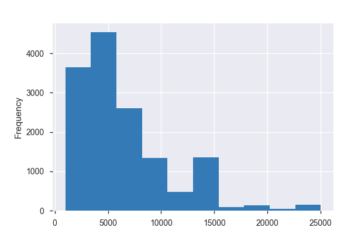

**Common Values**

| Value | Count | Frequency (%) |  |
| --- | --- | --- | --- |
| 4000 | 2080 | 14.5% |  |
| 2000 | 1225 | 8.5% |  |
| 5000 | 1155 | 8.0% |  |
| 15000 | 1024 | 7.1% |  |
| 7500 | 845 | 5.9% |  |
| 10000 | 825 | 5.7% |  |
| 3000 | 820 | 5.7% |  |
| 2500 | 590 | 4.1% |  |
| 7000 | 573 | 4.0% |  |
| 6000 | 489 | 3.4% |  |
| Other values (670) | 4733 | 33.0% |  |

**Extreme Values**

Minimum 5 values

| Value | Count | Frequency (%) |  |
| --- | --- | --- | --- |
| 1000 | 306 | 2.1% |  |
| 1050 | 3 | 0.0% |  |
| 1100 | 11 | 0.1% |  |
| 1112 | 1 | 0.0% |  |
| 1125 | 1 | 0.0% |  |

Maximum 5 values

| Value | Count | Frequency (%) |  |
| --- | --- | --- | --- |
| 23200 | 1 | 0.0% |  |
| 24000 | 3 | 0.0% |  |
| 24500 | 7 | 0.0% |  |
| 24800 | 1 | 0.0% |  |
| 25000 | 135 | 0.9% |  |

LoanOriginationQuarter  
Categorical

| Distinct count | 10 |
| --- | --- |
| Unique (%) | 0.1% |
| Missing (%) | 0.0% |
| Missing (n) | 0 |

| Q1 2012 | 2660 |
| --- | --- |
| Q4 2011 | 2342 |
| Q3 2011 | 1867 |
| Other values (7) | 7490 |

Toggle details

| Value | Count | Frequency (%) |  |
| --- | --- | --- | --- |
| Q1 2012 | 2660 | 18.5% |  |
| Q4 2011 | 2342 | 16.3% |  |
| Q3 2011 | 1867 | 13.0% |  |
| Q2 2012 | 1583 | 11.0% |  |
| Q2 2011 | 1529 | 10.6% |  |
| Q1 2011 | 1035 | 7.2% |  |
| Q4 2010 | 937 | 6.5% |  |
| Q2 2010 | 914 | 6.4% |  |
| Q3 2010 | 749 | 5.2% |  |
| Q1 2010 | 743 | 5.2% |  |

MonthlyLoanPayment  
Highly correlated

*This variable is highly correlated with `LoanOriginalAmount` and should be ignored for analysis*

| Correlation | 0.90506 |
| --- | --- |

OpenRevolvingAccounts  
Numeric

| Distinct count | 38 |
| --- | --- |
| Unique (%) | 0.3% |
| Missing (%) | 0.0% |
| Missing (n) | 0 |
| Infinite (%) | 0.0% |
| Infinite (n) | 0 |

| Mean | 6.3286 |
| --- | --- |
| Minimum | 0 |
| Maximum | 47 |
| Zeros (%) | 1.6% |

Toggle details

**Statistics**

Quantile statistics

| Minimum | 0 |
| --- | --- |
| 5-th percentile | 1 |
| Q1 | 3 |
| Median | 5 |
| Q3 | 8 |
| 95-th percentile | 14 |
| Maximum | 47 |
| Range | 47 |
| Interquartile range | 5 |

Descriptive statistics

| Standard deviation | 4.299 |
| --- | --- |
| Coef of variation | 0.67928 |
| Kurtosis | 4.3516 |
| Mean | 6.3286 |
| MAD | 3.2537 |
| Skewness | 1.5013 |
| Sum | 90873 |
| Variance | 18.481 |
| Memory size | 112.3 KiB |

**Histogram**

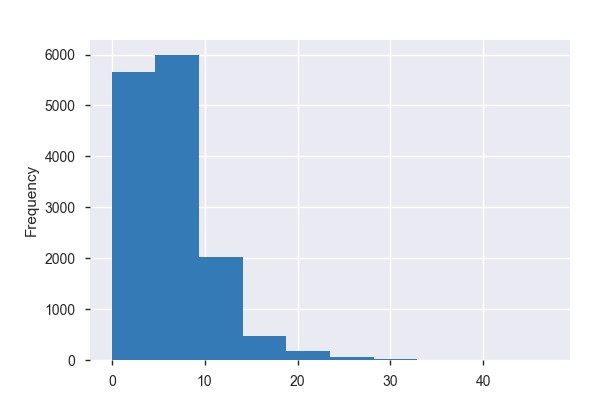

**Common Values**

| Value | Count | Frequency (%) |  |
| --- | --- | --- | --- |
| 4 | 1718 | 12.0% |  |
| 5 | 1612 | 11.2% |  |
| 3 | 1580 | 11.0% |  |
| 6 | 1393 | 9.7% |  |
| 2 | 1261 | 8.8% |  |
| 7 | 1208 | 8.4% |  |
| 8 | 1000 | 7.0% |  |
| 1 | 856 | 6.0% |  |
| 9 | 773 | 5.4% |  |
| 10 | 649 | 4.5% |  |
| Other values (28) | 2309 | 16.1% |  |

**Extreme Values**

Minimum 5 values

| Value | Count | Frequency (%) |  |
| --- | --- | --- | --- |
| 0 | 234 | 1.6% |  |
| 1 | 856 | 6.0% |  |
| 2 | 1261 | 8.8% |  |
| 3 | 1580 | 11.0% |  |
| 4 | 1718 | 12.0% |  |

Maximum 5 values

| Value | Count | Frequency (%) |  |
| --- | --- | --- | --- |
| 33 | 2 | 0.0% |  |
| 34 | 2 | 0.0% |  |
| 35 | 1 | 0.0% |  |
| 40 | 1 | 0.0% |  |
| 47 | 2 | 0.0% |  |

PercentFunded  
Numeric

| Distinct count | 333 |
| --- | --- |
| Unique (%) | 2.3% |
| Missing (%) | 0.0% |
| Missing (n) | 0 |
| Infinite (%) | 0.0% |
| Infinite (n) | 0 |

| Mean | 0.99527 |
| --- | --- |
| Minimum | 0.7 |
| Maximum | 1 |
| Zeros (%) | 0.0% |

Toggle details

**Statistics**

Quantile statistics

| Minimum | 0.7 |
| --- | --- |
| 5-th percentile | 1 |
| Q1 | 1 |
| Median | 1 |
| Q3 | 1 |
| 95-th percentile | 1 |
| Maximum | 1 |
| Range | 0.3 |
| Interquartile range | 0 |

Descriptive statistics

| Standard deviation | 0.032516 |
| --- | --- |
| Coef of variation | 0.032671 |
| Kurtosis | 54.515 |
| Mean | 0.99527 |
| MAD | 0.0092188 |
| Skewness | -7.3366 |
| Sum | 14291 |
| Variance | 0.0010573 |
| Memory size | 112.3 KiB |

**Histogram**

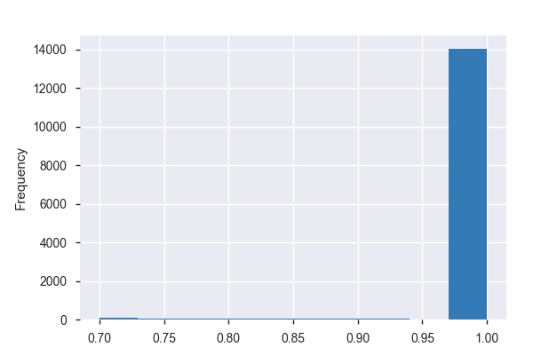

**Common Values**

| Value | Count | Frequency (%) |  |
| --- | --- | --- | --- |
| 1.0 | 13999 | 97.5% |  |
| 0.9086 | 3 | 0.0% |  |
| 0.7142 | 3 | 0.0% |  |
| 0.8347 | 2 | 0.0% |  |
| 0.7039 | 2 | 0.0% |  |
| 0.7168 | 2 | 0.0% |  |
| 0.7170000000000001 | 2 | 0.0% |  |
| 0.7292 | 2 | 0.0% |  |
| 0.7099 | 2 | 0.0% |  |
| 0.7032 | 2 | 0.0% |  |
| Other values (323) | 340 | 2.4% |  |

**Extreme Values**

Minimum 5 values

| Value | Count | Frequency (%) |  |
| --- | --- | --- | --- |
| 0.7 | 2 | 0.0% |  |
| 0.7005 | 2 | 0.0% |  |
| 0.7011 | 1 | 0.0% |  |
| 0.7013 | 1 | 0.0% |  |
| 0.7019 | 1 | 0.0% |  |

Maximum 5 values

| Value | Count | Frequency (%) |  |
| --- | --- | --- | --- |
| 0.9969 | 1 | 0.0% |  |
| 0.9992 | 1 | 0.0% |  |
| 0.9998 | 1 | 0.0% |  |
| 0.9999 | 1 | 0.0% |  |
| 1.0 | 13999 | 97.5% |  |

ProsperPaymentsOneMonthPlusLate  
Numeric

| Distinct count | 12 |
| --- | --- |
| Unique (%) | 0.1% |
| Missing (%) | 67.7% |
| Missing (n) | 9723 |
| Infinite (%) | 0.0% |
| Infinite (n) | 0 |

| Mean | 0.062554 |
| --- | --- |
| Minimum | 0 |
| Maximum | 19 |
| Zeros (%) | 31.5% |

Toggle details

**Statistics**

Quantile statistics

| Minimum | 0 |
| --- | --- |
| 5-th percentile | 0 |
| Q1 | 0 |
| Median | 0 |
| Q3 | 0 |
| 95-th percentile | 0 |
| Maximum | 19 |
| Range | 19 |
| Interquartile range | 0 |

Descriptive statistics

| Standard deviation | 0.59227 |
| --- | --- |
| Coef of variation | 9.4681 |
| Kurtosis | 456.66 |
| Mean | 0.062554 |
| MAD | 0.12209 |
| Skewness | 18.092 |
| Sum | 290 |
| Variance | 0.35078 |
| Memory size | 112.3 KiB |

**Histogram**

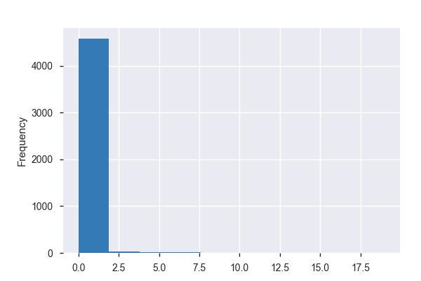

**Common Values**

| Value | Count | Frequency (%) |  |
| --- | --- | --- | --- |
| 0.0 | 4524 | 31.5% |  |
| 1.0 | 56 | 0.4% |  |
| 2.0 | 20 | 0.1% |  |
| 3.0 | 13 | 0.1% |  |
| 4.0 | 7 | 0.0% |  |
| 7.0 | 6 | 0.0% |  |
| 5.0 | 4 | 0.0% |  |
| 6.0 | 2 | 0.0% |  |
| 8.0 | 2 | 0.0% |  |
| 19.0 | 1 | 0.0% |  |
| (Missing) | 9723 | 67.7% |  |

**Extreme Values**

Minimum 5 values

| Value | Count | Frequency (%) |  |
| --- | --- | --- | --- |
| 0.0 | 4524 | 31.5% |  |
| 1.0 | 56 | 0.4% |  |
| 2.0 | 20 | 0.1% |  |
| 3.0 | 13 | 0.1% |  |
| 4.0 | 7 | 0.0% |  |

Maximum 5 values

| Value | Count | Frequency (%) |  |
| --- | --- | --- | --- |
| 6.0 | 2 | 0.0% |  |
| 7.0 | 6 | 0.0% |  |
| 8.0 | 2 | 0.0% |  |
| 18.0 | 1 | 0.0% |  |
| 19.0 | 1 | 0.0% |  |

ProsperPrincipalBorrowed  
Numeric

| Distinct count | 521 |
| --- | --- |
| Unique (%) | 3.6% |
| Missing (%) | 67.7% |
| Missing (n) | 9723 |
| Infinite (%) | 0.0% |
| Infinite (n) | 0 |

| Mean | 7054.4 |
| --- | --- |
| Minimum | 1000 |
| Maximum | 53100 |
| Zeros (%) | 0.0% |

Toggle details

**Statistics**

Quantile statistics

| Minimum | 1000 |
| --- | --- |
| 5-th percentile | 1000 |
| Q1 | 3000 |
| Median | 5000 |
| Q3 | 9000 |
| 95-th percentile | 20000 |
| Maximum | 53100 |
| Range | 52100 |
| Interquartile range | 6000 |

Descriptive statistics

| Standard deviation | 6272.6 |
| --- | --- |
| Coef of variation | 0.88917 |
| Kurtosis | 7.263 |
| Mean | 7054.4 |
| MAD | 4431.7 |
| Skewness | 2.2458 |
| Sum | 32704000 |
| Variance | 39345000 |
| Memory size | 112.3 KiB |

**Histogram**

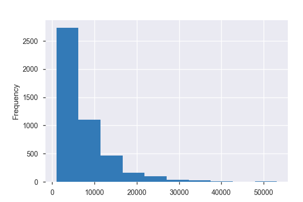

**Common Values**

| Value | Count | Frequency (%) |  |
| --- | --- | --- | --- |
| 5000.0 | 361 | 2.5% |  |
| 3000.0 | 299 | 2.1% |  |
| 1000.0 | 280 | 1.9% |  |
| 2000.0 | 259 | 1.8% |  |
| 4000.0 | 245 | 1.7% |  |
| 7500.0 | 211 | 1.5% |  |
| 10000.0 | 172 | 1.2% |  |
| 2500.0 | 152 | 1.1% |  |
| 6000.0 | 150 | 1.0% |  |
| 1500.0 | 145 | 1.0% |  |
| Other values (510) | 2362 | 16.4% |  |
| (Missing) | 9723 | 67.7% |  |

**Extreme Values**

Minimum 5 values

| Value | Count | Frequency (%) |  |
| --- | --- | --- | --- |
| 1000.0 | 280 | 1.9% |  |
| 1001.0 | 1 | 0.0% |  |
| 1050.0 | 2 | 0.0% |  |
| 1100.0 | 10 | 0.1% |  |
| 1107.0 | 1 | 0.0% |  |

Maximum 5 values

| Value | Count | Frequency (%) |  |
| --- | --- | --- | --- |
| 46000.0 | 1 | 0.0% |  |
| 50000.0 | 2 | 0.0% |  |
| 50600.0 | 1 | 0.0% |  |
| 52000.0 | 1 | 0.0% |  |
| 53100.0 | 1 | 0.0% |  |

ProsperPrincipalOutstanding  
Numeric

| Distinct count | 2769 |
| --- | --- |
| Unique (%) | 19.3% |
| Missing (%) | 67.7% |
| Missing (n) | 9723 |
| Infinite (%) | 0.0% |
| Infinite (n) | 0 |

| Mean | 1904.2 |
| --- | --- |
| Minimum | 0 |
| Maximum | 21524 |
| Zeros (%) | 9.5% |

Toggle details

**Statistics**

Quantile statistics

| Minimum | 0 |
| --- | --- |
| 5-th percentile | 0 |
| Q1 | 0 |
| Median | 769.03 |
| Q3 | 2885.1 |
| 95-th percentile | 7237.9 |
| Maximum | 21524 |
| Range | 21524 |
| Interquartile range | 2885.1 |

Descriptive statistics

| Standard deviation | 2754.1 |
| --- | --- |
| Coef of variation | 1.4464 |
| Kurtosis | 6.8215 |
| Mean | 1904.2 |
| MAD | 2008.5 |
| Skewness | 2.2605 |
| Sum | 8827800 |
| Variance | 7585300 |
| Memory size | 112.3 KiB |

**Histogram**

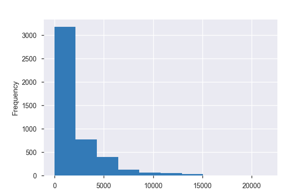

**Common Values**

| Value | Count | Frequency (%) |  |
| --- | --- | --- | --- |
| 0.0 | 1361 | 9.5% |  |
| 0.01 | 288 | 2.0% |  |
| 0.02 | 86 | 0.6% |  |
| 0.03 | 27 | 0.2% |  |
| 0.04 | 22 | 0.2% |  |
| 0.05 | 6 | 0.0% |  |
| 6233.29 | 5 | 0.0% |  |
| 0.13 | 4 | 0.0% |  |
| 3328.07 | 3 | 0.0% |  |
| 0.37 | 3 | 0.0% |  |
| Other values (2758) | 2831 | 19.7% |  |
| (Missing) | 9723 | 67.7% |  |

**Extreme Values**

Minimum 5 values

| Value | Count | Frequency (%) |  |
| --- | --- | --- | --- |
| 0.0 | 1361 | 9.5% |  |
| 0.01 | 288 | 2.0% |  |
| 0.02 | 86 | 0.6% |  |
| 0.03 | 27 | 0.2% |  |
| 0.04 | 22 | 0.2% |  |

Maximum 5 values

| Value | Count | Frequency (%) |  |
| --- | --- | --- | --- |
| 20789.14 | 1 | 0.0% |  |
| 21289.72 | 1 | 0.0% |  |
| 21514.38 | 1 | 0.0% |  |
| 21517.25 | 1 | 0.0% |  |
| 21523.79 | 1 | 0.0% |  |

RevolvingCreditBalance  
Numeric

| Distinct count | 10402 |
| --- | --- |
| Unique (%) | 72.4% |
| Missing (%) | 0.0% |
| Missing (n) | 0 |
| Infinite (%) | 0.0% |
| Infinite (n) | 0 |

| Mean | 16210 |
| --- | --- |
| Minimum | 0 |
| Maximum | 879780 |
| Zeros (%) | 4.9% |

Toggle details

**Statistics**

Quantile statistics

| Minimum | 0 |
| --- | --- |
| 5-th percentile | 6.9 |
| Q1 | 1991.5 |
| Median | 6567 |
| Q3 | 16748 |
| 95-th percentile | 59803 |
| Maximum | 879780 |
| Range | 879780 |
| Interquartile range | 14756 |

Descriptive statistics

| Standard deviation | 34495 |
| --- | --- |
| Coef of variation | 2.128 |
| Kurtosis | 138.39 |
| Mean | 16210 |
| MAD | 16517 |
| Skewness | 8.7559 |
| Sum | 232760000 |
| Variance | 1189900000 |
| Memory size | 112.3 KiB |

**Histogram**

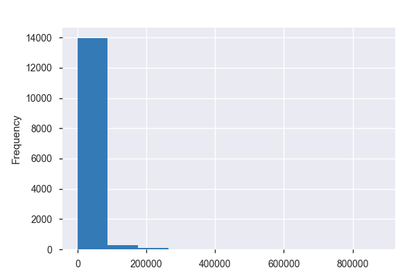

**Common Values**

| Value | Count | Frequency (%) |  |
| --- | --- | --- | --- |
| 0.0 | 699 | 4.9% |  |
| 39.0 | 11 | 0.1% |  |
| 59.0 | 10 | 0.1% |  |
| 521.0 | 9 | 0.1% |  |
| 50.0 | 8 | 0.1% |  |
| 292.0 | 8 | 0.1% |  |
| 506.0 | 7 | 0.0% |  |
| 124.0 | 7 | 0.0% |  |
| 75.0 | 7 | 0.0% |  |
| 777.0 | 7 | 0.0% |  |
| Other values (10392) | 13586 | 94.6% |  |

**Extreme Values**

Minimum 5 values

| Value | Count | Frequency (%) |  |
| --- | --- | --- | --- |
| 0.0 | 699 | 4.9% |  |
| 1.0 | 3 | 0.0% |  |
| 2.0 | 1 | 0.0% |  |
| 3.0 | 5 | 0.0% |  |
| 4.0 | 4 | 0.0% |  |

Maximum 5 values

| Value | Count | Frequency (%) |  |
| --- | --- | --- | --- |
| 657033.0 | 1 | 0.0% |  |
| 735935.0 | 1 | 0.0% |  |
| 877847.0 | 1 | 0.0% |  |
| 878859.0 | 1 | 0.0% |  |
| 879785.0 | 1 | 0.0% |  |

ScorexChangeAtTimeOfListing  
Numeric

| Distinct count | 331 |
| --- | --- |
| Unique (%) | 2.3% |
| Missing (%) | 67.8% |
| Missing (n) | 9739 |
| Infinite (%) | 0.0% |
| Infinite (n) | 0 |

| Mean | -1.4195 |
| --- | --- |
| Minimum | -194 |
| Maximum | 235 |
| Zeros (%) | 0.3% |

Toggle details

**Statistics**

Quantile statistics

| Minimum | -194 |
| --- | --- |
| 5-th percentile | -87 |
| Q1 | -33 |
| Median | -4 |
| Q3 | 28 |
| 95-th percentile | 91 |
| Maximum | 235 |
| Range | 429 |
| Interquartile range | 61 |

Descriptive statistics

| Standard deviation | 53.272 |
| --- | --- |
| Coef of variation | -37.529 |
| Kurtosis | 0.76681 |
| Mean | -1.4195 |
| MAD | 40.379 |
| Skewness | 0.28438 |
| Sum | -6558 |
| Variance | 2837.9 |
| Memory size | 112.3 KiB |

**Histogram**

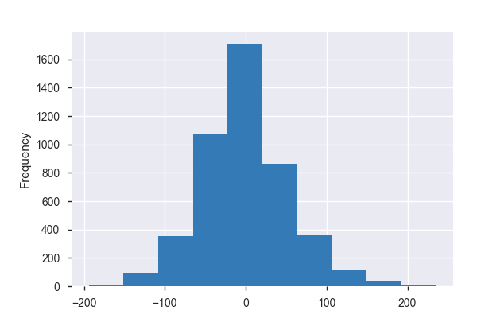

**Common Values**

| Value | Count | Frequency (%) |  |
| --- | --- | --- | --- |
| -5.0 | 57 | 0.4% |  |
| -8.0 | 56 | 0.4% |  |
| 8.0 | 55 | 0.4% |  |
| 3.0 | 51 | 0.4% |  |
| -13.0 | 50 | 0.3% |  |
| -30.0 | 49 | 0.3% |  |
| -15.0 | 49 | 0.3% |  |
| -17.0 | 46 | 0.3% |  |
| 9.0 | 46 | 0.3% |  |
| 0.0 | 46 | 0.3% |  |
| Other values (320) | 4115 | 28.7% |  |
| (Missing) | 9739 | 67.8% |  |

**Extreme Values**

Minimum 5 values

| Value | Count | Frequency (%) |  |
| --- | --- | --- | --- |
| -194.0 | 1 | 0.0% |  |
| -173.0 | 1 | 0.0% |  |
| -172.0 | 1 | 0.0% |  |
| -167.0 | 1 | 0.0% |  |
| -164.0 | 2 | 0.0% |  |

Maximum 5 values

| Value | Count | Frequency (%) |  |
| --- | --- | --- | --- |
| 190.0 | 1 | 0.0% |  |
| 196.0 | 1 | 0.0% |  |
| 208.0 | 1 | 0.0% |  |
| 221.0 | 1 | 0.0% |  |
| 235.0 | 1 | 0.0% |  |

StatedMonthlyIncome  
Numeric

| Distinct count | 2539 |
| --- | --- |
| Unique (%) | 17.7% |
| Missing (%) | 0.0% |
| Missing (n) | 0 |
| Infinite (%) | 0.0% |
| Infinite (n) | 0 |

| Mean | 5679.7 |
| --- | --- |
| Minimum | 0 |
| Maximum | 1750000 |
| Zeros (%) | 1.6% |

Toggle details

**Statistics**

Quantile statistics

| Minimum | 0 |
| --- | --- |
| 5-th percentile | 1500 |
| Q1 | 3166.7 |
| Median | 4583.3 |
| Q3 | 6708.3 |
| 95-th percentile | 12083 |
| Maximum | 1750000 |
| Range | 1750000 |
| Interquartile range | 3541.7 |

Descriptive statistics

| Standard deviation | 15700 |
| --- | --- |
| Coef of variation | 2.7642 |
| Kurtosis | 10674 |
| Mean | 5679.7 |
| MAD | 2856.8 |
| Skewness | 97.603 |
| Sum | 81556000 |
| Variance | 246490000 |
| Memory size | 112.3 KiB |

**Histogram**

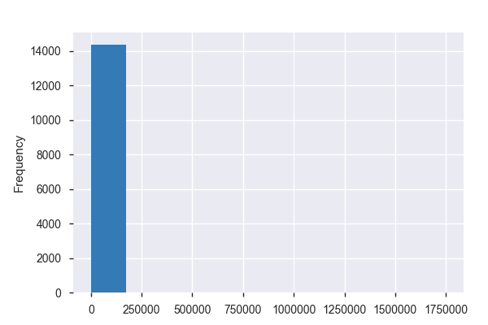

**Common Values**

| Value | Count | Frequency (%) |  |
| --- | --- | --- | --- |
| 5000.0 | 441 | 3.1% |  |
| 4166.666667 | 428 | 3.0% |  |
| 3333.333333 | 408 | 2.8% |  |
| 3750.0 | 340 | 2.4% |  |
| 2500.0 | 323 | 2.2% |  |
| 5416.666667 | 294 | 2.0% |  |
| 6250.0 | 277 | 1.9% |  |
| 6666.666667 | 268 | 1.9% |  |
| 4583.333333 | 257 | 1.8% |  |
| 2916.666667 | 247 | 1.7% |  |
| Other values (2529) | 11076 | 77.1% |  |

**Extreme Values**

Minimum 5 values

| Value | Count | Frequency (%) |  |
| --- | --- | --- | --- |
| 0.0 | 225 | 1.6% |  |
| 0.083333 | 1 | 0.0% |  |
| 1.416667 | 1 | 0.0% |  |
| 1.666667 | 1 | 0.0% |  |
| 1.833333 | 1 | 0.0% |  |

Maximum 5 values

| Value | Count | Frequency (%) |  |
| --- | --- | --- | --- |
| 79166.666667 | 1 | 0.0% |  |
| 96266.5 | 1 | 0.0% |  |
| 100000.0 | 1 | 0.0% |  |
| 483333.333333 | 1 | 0.0% |  |
| 1750002.916667 | 1 | 0.0% |  |

Term  
Numeric

| Distinct count | 3 |
| --- | --- |
| Unique (%) | 0.0% |
| Missing (%) | 0.0% |
| Missing (n) | 0 |
| Infinite (%) | 0.0% |
| Infinite (n) | 0 |

| Mean | 38.285 |
| --- | --- |
| Minimum | 12 |
| Maximum | 60 |
| Zeros (%) | 0.0% |

Toggle details

**Statistics**

Quantile statistics

| Minimum | 12 |
| --- | --- |
| 5-th percentile | 36 |
| Q1 | 36 |
| Median | 36 |
| Q3 | 36 |
| 95-th percentile | 60 |
| Maximum | 60 |
| Range | 48 |
| Interquartile range | 0 |

Descriptive statistics

| Standard deviation | 9.3579 |
| --- | --- |
| Coef of variation | 0.24443 |
| Kurtosis | 2.7713 |
| Mean | 38.285 |
| MAD | 5.5653 |
| Skewness | 0.85919 |
| Sum | 549732 |
| Variance | 87.57 |
| Memory size | 112.3 KiB |

**Histogram**

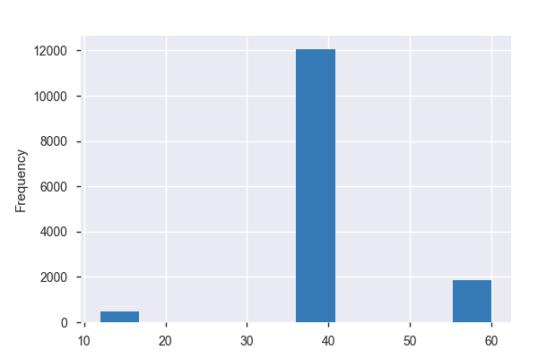

**Common Values**

| Value | Count | Frequency (%) |  |
| --- | --- | --- | --- |
| 36 | 12046 | 83.9% |  |
| 60 | 1840 | 12.8% |  |
| 12 | 473 | 3.3% |  |

**Extreme Values**

Minimum 5 values

| Value | Count | Frequency (%) |  |
| --- | --- | --- | --- |
| 12 | 473 | 3.3% |  |
| 36 | 12046 | 83.9% |  |
| 60 | 1840 | 12.8% |  |

Maximum 5 values

| Value | Count | Frequency (%) |  |
| --- | --- | --- | --- |
| 12 | 473 | 3.3% |  |
| 36 | 12046 | 83.9% |  |
| 60 | 1840 | 12.8% |  |

TotalInquiries  
Numeric

| Distinct count | 43 |
| --- | --- |
| Unique (%) | 0.3% |
| Missing (%) | 0.0% |
| Missing (n) | 0 |
| Infinite (%) | 0.0% |
| Infinite (n) | 0 |

| Mean | 4.3008 |
| --- | --- |
| Minimum | 0 |
| Maximum | 71 |
| Zeros (%) | 9.1% |

Toggle details

**Statistics**

Quantile statistics

| Minimum | 0 |
| --- | --- |
| 5-th percentile | 0 |
| Q1 | 2 |
| Median | 3 |
| Q3 | 6 |
| 95-th percentile | 12 |
| Maximum | 71 |
| Range | 71 |
| Interquartile range | 4 |

Descriptive statistics

| Standard deviation | 4.0735 |
| --- | --- |
| Coef of variation | 0.94714 |
| Kurtosis | 16.991 |
| Mean | 4.3008 |
| MAD | 2.8698 |
| Skewness | 2.6889 |
| Sum | 61755 |
| Variance | 16.593 |
| Memory size | 112.3 KiB |

**Histogram**

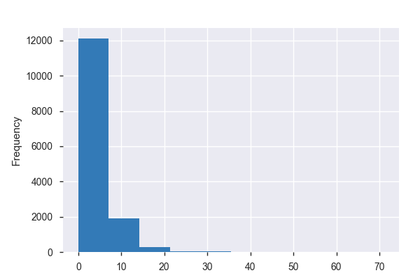

**Common Values**

| Value | Count | Frequency (%) |  |
| --- | --- | --- | --- |
| 2.0 | 2203 | 15.3% |  |
| 1.0 | 2096 | 14.6% |  |
| 3.0 | 1933 | 13.5% |  |
| 4.0 | 1656 | 11.5% |  |
| 5.0 | 1355 | 9.4% |  |
| 0.0 | 1303 | 9.1% |  |
| 6.0 | 850 | 5.9% |  |
| 7.0 | 707 | 4.9% |  |
| 8.0 | 533 | 3.7% |  |
| 9.0 | 412 | 2.9% |  |
| Other values (33) | 1311 | 9.1% |  |

**Extreme Values**

Minimum 5 values

| Value | Count | Frequency (%) |  |
| --- | --- | --- | --- |
| 0.0 | 1303 | 9.1% |  |
| 1.0 | 2096 | 14.6% |  |
| 2.0 | 2203 | 15.3% |  |
| 3.0 | 1933 | 13.5% |  |
| 4.0 | 1656 | 11.5% |  |

Maximum 5 values

| Value | Count | Frequency (%) |  |
| --- | --- | --- | --- |
| 40.0 | 1 | 0.0% |  |
| 46.0 | 1 | 0.0% |  |
| 51.0 | 1 | 0.0% |  |
| 63.0 | 1 | 0.0% |  |
| 71.0 | 1 | 0.0% |  |

TotalProsperLoans  
Numeric

| Distinct count | 8 |
| --- | --- |
| Unique (%) | 0.1% |
| Missing (%) | 67.7% |
| Missing (n) | 9723 |
| Infinite (%) | 0.0% |
| Infinite (n) | 0 |

| Mean | 1.384 |
| --- | --- |
| Minimum | 1 |
| Maximum | 7 |
| Zeros (%) | 0.0% |

Toggle details

**Statistics**

Quantile statistics

| Minimum | 1 |
| --- | --- |
| 5-th percentile | 1 |
| Q1 | 1 |
| Median | 1 |
| Q3 | 2 |
| 95-th percentile | 3 |
| Maximum | 7 |
| Range | 6 |
| Interquartile range | 1 |

Descriptive statistics

| Standard deviation | 0.69496 |
| --- | --- |
| Coef of variation | 0.50216 |
| Kurtosis | 6.7092 |
| Mean | 1.384 |
| MAD | 0.54462 |
| Skewness | 2.2424 |
| Sum | 6416 |
| Variance | 0.48297 |
| Memory size | 112.3 KiB |

**Histogram**

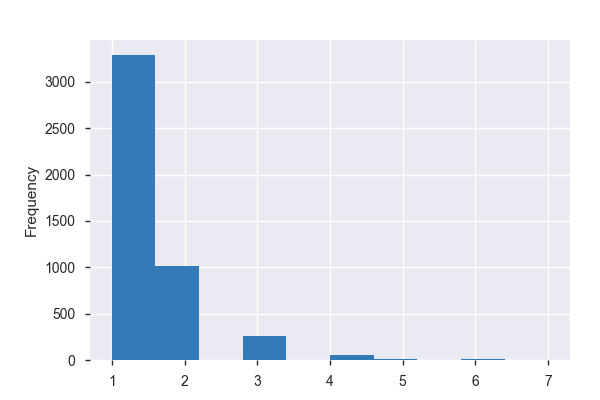

**Common Values**

| Value | Count | Frequency (%) |  |
| --- | --- | --- | --- |
| 1.0 | 3288 | 22.9% |  |
| 2.0 | 1017 | 7.1% |  |
| 3.0 | 259 | 1.8% |  |
| 4.0 | 51 | 0.4% |  |
| 5.0 | 14 | 0.1% |  |
| 6.0 | 6 | 0.0% |  |
| 7.0 | 1 | 0.0% |  |
| (Missing) | 9723 | 67.7% |  |

**Extreme Values**

Minimum 5 values

| Value | Count | Frequency (%) |  |
| --- | --- | --- | --- |
| 1.0 | 3288 | 22.9% |  |
| 2.0 | 1017 | 7.1% |  |
| 3.0 | 259 | 1.8% |  |
| 4.0 | 51 | 0.4% |  |
| 5.0 | 14 | 0.1% |  |

Maximum 5 values

| Value | Count | Frequency (%) |  |
| --- | --- | --- | --- |
| 3.0 | 259 | 1.8% |  |
| 4.0 | 51 | 0.4% |  |
| 5.0 | 14 | 0.1% |  |
| 6.0 | 6 | 0.0% |  |
| 7.0 | 1 | 0.0% |  |

TradesNeverDelinquent (percentage)  
Numeric

| Distinct count | 76 |
| --- | --- |
| Unique (%) | 0.5% |
| Missing (%) | 0.0% |
| Missing (n) | 0 |
| Infinite (%) | 0.0% |
| Infinite (n) | 0 |

| Mean | 0.88923 |
| --- | --- |
| Minimum | 0.1 |
| Maximum | 1 |
| Zeros (%) | 0.0% |

Toggle details

**Statistics**

Quantile statistics

| Minimum | 0.1 |
| --- | --- |
| 5-th percentile | 0.62 |
| Q1 | 0.82 |
| Median | 0.94 |
| Q3 | 1 |
| 95-th percentile | 1 |
| Maximum | 1 |
| Range | 0.9 |
| Interquartile range | 0.18 |

Descriptive statistics

| Standard deviation | 0.13369 |
| --- | --- |
| Coef of variation | 0.15034 |
| Kurtosis | 1.7411 |
| Mean | 0.88923 |
| MAD | 0.10632 |
| Skewness | -1.3995 |
| Sum | 12768 |
| Variance | 0.017872 |
| Memory size | 112.3 KiB |

**Histogram**

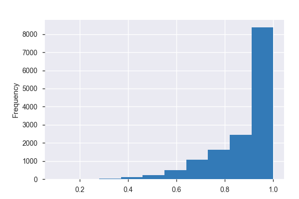

**Common Values**

| Value | Count | Frequency (%) |  |
| --- | --- | --- | --- |
| 1.0 | 5425 | 37.8% |  |
| 0.96 | 544 | 3.8% |  |
| 0.95 | 474 | 3.3% |  |
| 0.9 | 472 | 3.3% |  |
| 0.94 | 432 | 3.0% |  |
| 0.93 | 397 | 2.8% |  |
| 0.88 | 396 | 2.8% |  |
| 0.92 | 390 | 2.7% |  |
| 0.97 | 349 | 2.4% |  |
| 0.8 | 327 | 2.3% |  |
| Other values (66) | 5153 | 35.9% |  |

**Extreme Values**

Minimum 5 values

| Value | Count | Frequency (%) |  |
| --- | --- | --- | --- |
| 0.1 | 1 | 0.0% |  |
| 0.17 | 1 | 0.0% |  |
| 0.22 | 2 | 0.0% |  |
| 0.23 | 1 | 0.0% |  |
| 0.24 | 1 | 0.0% |  |

Maximum 5 values

| Value | Count | Frequency (%) |  |
| --- | --- | --- | --- |
| 0.95 | 474 | 3.3% |  |
| 0.96 | 544 | 3.8% |  |
| 0.97 | 349 | 2.4% |  |
| 0.98 | 58 | 0.4% |  |
| 1.0 | 5425 | 37.8% |  |

home+income  
Numeric

| Distinct count | 3 |
| --- | --- |
| Unique (%) | 0.0% |
| Missing (%) | 0.0% |
| Missing (n) | 0 |
| Infinite (%) | 0.0% |
| Infinite (n) | 0 |

| Mean | 1.4011 |
| --- | --- |
| Minimum | 0 |
| Maximum | 2 |
| Zeros (%) | 7.8% |

Toggle details

**Statistics**

Quantile statistics

| Minimum | 0 |
| --- | --- |
| 5-th percentile | 0 |
| Q1 | 1 |
| Median | 1 |
| Q3 | 2 |
| 95-th percentile | 2 |
| Maximum | 2 |
| Range | 2 |
| Interquartile range | 1 |

Descriptive statistics

| Standard deviation | 0.62871 |
| --- | --- |
| Coef of variation | 0.44871 |
| Kurtosis | -0.61989 |
| Mean | 1.4011 |
| MAD | 0.57329 |
| Skewness | -0.55969 |
| Sum | 20119 |
| Variance | 0.39528 |
| Memory size | 112.3 KiB |

**Histogram**

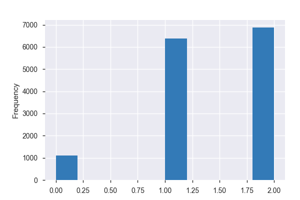

**Common Values**

| Value | Count | Frequency (%) |  |
| --- | --- | --- | --- |
| 2 | 6873 | 47.9% |  |
| 1 | 6373 | 44.4% |  |
| 0 | 1113 | 7.8% |  |

**Extreme Values**

Minimum 5 values

| Value | Count | Frequency (%) |  |
| --- | --- | --- | --- |
| 0 | 1113 | 7.8% |  |
| 1 | 6373 | 44.4% |  |
| 2 | 6873 | 47.9% |  |

Maximum 5 values

| Value | Count | Frequency (%) |  |
| --- | --- | --- | --- |
| 0 | 1113 | 7.8% |  |
| 1 | 6373 | 44.4% |  |
| 2 | 6873 | 47.9% |  |

indebtedness_rate  
Highly correlated

*This variable is highly correlated with `StatedMonthlyIncome` and should be ignored for analysis*

| Correlation | 0.95013 |
| --- | --- |

reliable  
Highly correlated

*This variable is highly correlated with `home+income` and should be ignored for analysis*

| Correlation | 0.91271 |
| --- | --- |

# Sample

|  | Term | LenderYield | ListingCategory (numeric) | BorrowerState | EmploymentStatus | EmploymentStatusDuration | IsBorrowerHomeowner | CurrentlyInGroup | CreditScoreRangeLower | CreditScoreRangeUpper | CurrentCreditLines | OpenRevolvingAccounts | TotalInquiries | CurrentDelinquencies | RevolvingCreditBalance | AvailableBankcardCredit | TradesNeverDelinquent (percentage) | DebtToIncomeRatio | IncomeVerifiable | StatedMonthlyIncome | TotalProsperLoans | ProsperPaymentsOneMonthPlusLate | ProsperPrincipalBorrowed | ProsperPrincipalOutstanding | ScorexChangeAtTimeOfListing | LoanMonthsSinceOrigination | LoanOriginalAmount | LoanOriginationQuarter | MonthlyLoanPayment | … |
| --- | --- | --- | --- | --- | --- | --- | --- | --- | --- | --- | --- | --- | --- | --- | --- | --- | --- | --- | --- | --- | --- | --- | --- | --- | --- | --- | --- | --- | --- | --- |
| 0 | 36 | 0.1905 | 1 | CA | Full-time | 6.0 | False | False | 680.0 | 699.0 | 6.0 | 5 | 5.0 | 0.0 | 35884.0 | 41447.0 | 1.00 | 0.14 | True | 6500.000000 | NaN | NaN | NaN | NaN | NaN | 49 | 3900 | Q1 2010 | 145.04 | … |
| 1 | 60 | 0.1296 | 1 | CT | Employed | 529.0 | True | False | 760.0 | 779.0 | 25.0 | 15 | 1.0 | 0.0 | 212049.0 | 28545.0 | 1.00 | 0.19 | True | 22916.666667 | NaN | NaN | NaN | NaN | NaN | 23 | 25000 | Q2 2012 | 581.19 | … |
| 2 | 36 | 0.3400 | 1 | CA | Full-time | 103.0 | True | False | 660.0 | 679.0 | 9.0 | 6 | 15.0 | 0.0 | 12725.0 | 1124.0 | 0.81 | 0.33 | True | 4666.666667 | NaN | NaN | NaN | NaN | NaN | 39 | 3000 | Q4 2010 | 135.71 | … |
| 3 | 36 | 0.3049 | 1 | OR | Employed | 0.0 | True | False | 760.0 | 779.0 | 7.0 | 4 | 5.0 | 1.0 | 92.0 | 5158.0 | 0.88 | 0.34 | True | 5000.000000 | NaN | NaN | NaN | NaN | NaN | 28 | 7500 | Q4 2011 | 324.54 | … |
| 4 | 36 | 0.3099 | 1 | IN | Employed | 122.0 | True | False | 680.0 | 699.0 | 9.0 | 2 | 3.0 | 0.0 | 14589.0 | 411.0 | 1.00 | 0.42 | True | 5416.666667 | NaN | NaN | NaN | NaN | NaN | 34 | 7500 | Q2 2011 | 326.62 | … |